# Prediction Assignment Writeup

Ashish A

February 12, 2018

# Introduction

Using devices such as Jawbone Up, Nike FuelBand, and Fitbit it is now possible to collect a large amount of data about personal activity relatively inexpensively. These type of devices are part of the quantified self movement - a group of enthusiasts who take measurements about themselves regularly to improve their health, to find patterns in their behavior, or because they are tech geeks.

One thing that people regularly do is quantify how much of a particular activity they do, but they rarely quantify how well they do it. In this project, your goal will be to use data from accelerometers on the belt, forearm, arm, and dumbell of 6 participants. They were asked to perform barbell lifts correctly and incorrectly in 5 different ways.

More information is available from the website here: http://groupware.les.inf.puc-rio.br/har (see the section on the Weight Lifting Exercise Dataset).

The goal of this project is to predict the manner in which the participants did the exercise. This is the classe variable of the training set, which classifies the correct and incorrect outcomes into A, B, C, D, and E categories. This report describes: - how the model for the project was built, its cross validation, expected out of sample error calculation, and the choices made.

It was used successfully to accurately predict all 20 different test cases on the Coursera website.

# Load Source Data

The training data for this project are available here:

https://d396qusza40orc.cloudfront.net/predmachlearn/pml-training.csv

The test data are available here:

https://d396qusza40orc.cloudfront.net/predmachlearn/pml-testing.csv

```r
library(caret)
```

```r
library(rpart)
library(rpart.plot)
library(rattle)
library(randomForest)
library(corrplot)
setwd("C:/Users/agarwala/Desktop/R/App/coursera assignments")
train.original <- read.csv("pml-training.csv", na.strings = c("NA", "#DIV/0!", ""))
test.original  <- read.csv("pml-testing.csv",  na.strings = c("NA", "#DIV/0!", ""))
dim(train.original)
```

```
## [1] 19622   160
```

```r
dim(test.original)
```

```
## [1]  20 160
```

We have read the training and test data in two separate dataframes. Training data contains 19622 observations of 160 variables whereas test data contains 20 observations of 160 variables.

# Data Cleaning

First we remove the columns which contains NA values. This reduces the number of variables down to 60.

```r
train.cleanNA <- train.original[ , colSums(is.na(train.original)) == 0]
dim(train.cleanNA)
```

```
## [1] 19622    60
```

Then we remove the first 7 features since they are related to the time-series or are not numeric and are mainly for information purpose. The variables which have the text “belt, forearm, arm, or dumbell” in its name contains actual data for analysis. We also keep the “classe” variable in a separate frame so that we can perform the correlation analysis on the remaining variables.

```r
train.clean <- train.cleanNA[, 8:59]
train.classe <- train.cleanNA[, 60, drop=FALSE]
dim(train.clean)
```

```
## [1] 19622    52
```

```r
dim(train.classe)
```

```
## [1] 19622     1
```

## Correlation Analysis

We use findCorrelation to find the correlated variables. We then remove these from our clean dataset. We then merge this dataframe with the “classe” variable dataframe.

As a result we finally get a dataframe which is now clean and ready for creating model.

```r
train.clean <- train.clean[sapply(train.clean, is.numeric)]
train.cor = cor(train.clean)
corr.matrix = findCorrelation(train.cor, cutoff=0.75, verbose = TRUE) # putt any value as a "cutoff"
```

```
## Compare row 10  and column  1 with corr  0.992
##   Means:  0.27 vs 0.168 so flagging column 10
## Compare row 1  and column  9 with corr  0.925
##   Means:  0.25 vs 0.164 so flagging column 1
## Compare row 9  and column  4 with corr  0.928
##   Means:  0.233 vs 0.161 so flagging column 9
## Compare row 22  and column  4 with corr  0.759
##   Means:  0.224 vs 0.158 so flagging column 22
## Compare row 4  and column  3 with corr  0.762
##   Means:  0.2 vs 0.155 so flagging column 4
## Compare row 36  and column  29 with corr  0.849
##   Means:  0.257 vs 0.153 so flagging column 36
## Compare row 8  and column  2 with corr  0.966
##   Means:  0.24 vs 0.148 so flagging column 8
## Compare row 2  and column  11 with corr  0.884
##   Means:  0.223 vs 0.144 so flagging column 2
## Compare row 37  and column  38 with corr  0.769
##   Means:  0.194 vs 0.141 so flagging column 37
## Compare row 35  and column  30 with corr  0.773
##   Means:  0.191 vs 0.139 so flagging column 35
## Compare row 38  and column  5 with corr  0.781
##   Means:  0.174 vs 0.137 so flagging column 38
## Compare row 21  and column  24 with corr  0.814
##   Means:  0.173 vs 0.136 so flagging column 21
## Compare row 34  and column  28 with corr  0.808
##   Means:  0.173 vs 0.133 so flagging column 34
## Compare row 23  and column  26 with corr  0.779
##   Means:  0.14 vs 0.132 so flagging column 23
## Compare row 25  and column  24 with corr  0.792
##   Means:  0.142 vs 0.132 so flagging column 25
## Compare row 12  and column  13 with corr  0.779
##   Means:  0.12 vs 0.131 so flagging column 13
## Compare row 48  and column  51 with corr  0.772
##   Means:  0.147 vs 0.131 so flagging column 48
## Compare row 19  and column  18 with corr  0.918
##   Means:  0.098 vs 0.131 so flagging column 18
## Compare row 46  and column  45 with corr  0.846
##   Means:  0.13 vs 0.133 so flagging column 45
## Compare row 46  and column  31 with corr  0.914
##   Means:  0.107 vs 0.135 so flagging column 31
## Compare row 46  and column  33 with corr  0.933
##   Means:  0.081 vs 0.138 so flagging column 33
## All correlations <= 0.75
```

```r
corr.matrix = sort(corr.matrix)
train.reduced = train.clean[,-c(corr.matrix)]
train.reduced<- data.frame(train.reduced, train.classe)
dim (train.reduced)
```

```
## [1] 19622    32
```

After removing the correlated variables, the number of variables are reduced to 32.

# Cross Validation of Data

Before we start building and analysing our prediction models, we will partition the original training data into two parts. We will use these two subsets to do cross validation of our model.

Here we have subsetted our training data by 60:40 ratio. We will use the first dataset (train.train) for fitting the model and the second dataset (train.test) to cross validate the model.

```r
set.seed(12345)
train.partition <- createDataPartition(train.reduced$classe, p=0.6, list=FALSE)
train.train <- train.reduced[train.partition,]
train.test <- train.reduced[-train.partition,]
dim(train.train)
```

```
## [1] 11776    32
```

```r
dim(train.test)
```

```
## [1] 7846   32
```

# Prediction Model Building

We will build two models for analysis - Random Forest and Decision Tree. We will use the first subset (train.train) of training data to fit the model. We then use ths model to predict values for “classe” variable for second subset (train.test). Then we display the confusion matrix to analyse the results.

## A. Random Forest

```r
rf.model <- randomForest(classe ~ ., data = train.train, ntree = 500)
rf.model
```

```
##
## Call:
##  randomForest(formula = classe ~ ., data = train.train, ntree = 500)
##                Type of random forest: classification
##                      Number of trees: 500
## No. of variables tried at each split: 5
##
##         OOB estimate of  error rate: 1.1%
## Confusion matrix:
##      A    B    C    D    E class.error
## A 3342    3    2    0    1 0.001792115
## B   19 2245   14    0    1 0.014918824
## C    0   20 2014   19    1 0.019474197
## D    0    0   32 1893    5 0.019170984
## E    0    1    4    8 2152 0.006004619
```

```r
rf.predict <- predict(rf.model, newdata=train.test)
cm.rf.test <- confusionMatrix(rf.predict, train.test$classe)
cm.rf.test
```

```
## Confusion Matrix and Statistics
##
##           Reference
## Prediction    A    B    C    D    E
##          A 2225    8    0    0    0
##          B    7 1504   12    0    1
##          C    0    5 1348   13    1
##          D    0    0    7 1269    5
##          E    0    1    1    4 1435
##
## Overall Statistics
##
##                Accuracy : 0.9917
##                  95% CI : (0.9895, 0.9936)
##     No Information Rate : 0.2845
##     P-Value [Acc > NIR] : < 2.2e-16
##
##                   Kappa : 0.9895
##  Mcnemar's Test P-Value : NA
##
## Statistics by Class:
##
##                      Class: A Class: B Class: C Class: D Class: E
## Sensitivity            0.9969   0.9908   0.9854   0.9868   0.9951
## Specificity            0.9986   0.9968   0.9971   0.9982   0.9991
## Pos Pred Value         0.9964   0.9869   0.9861   0.9906   0.9958
## Neg Pred Value         0.9988   0.9978   0.9969   0.9974   0.9989
## Prevalence             0.2845   0.1935   0.1744   0.1639   0.1838
## Detection Rate         0.2836   0.1917   0.1718   0.1617   0.1829
## Detection Prevalence   0.2846   0.1942   0.1742   0.1633   0.1837
## Balanced Accuracy      0.9977   0.9938   0.9912   0.9925   0.9971
```

## B. Decision Tree

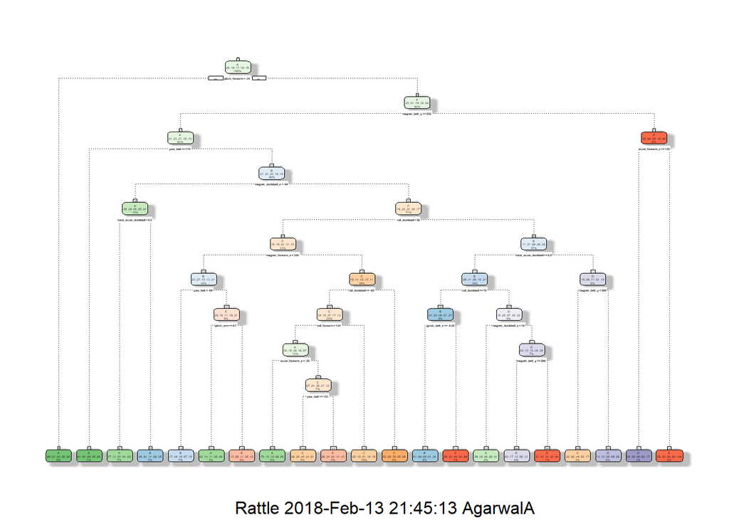

```r
dt.model <- rpart(classe ~ ., data = train.train, method="class")
fancyRpartPlot(dt.model)
```

```r
dt.predict <- predict(dt.model, newdata=train.test, type="class")
cm.dt.test <- confusionMatrix(dt.predict, train.test$classe)
cm.dt.test
```

```
## Confusion Matrix and Statistics
##
##           Reference
## Prediction    A    B    C    D    E
##          A 1833  236   71   96   33
##          B  130  849  184   67  197
##          C  115  194  995  251  217
##          D   72  142   61  731  103
##          E   82   97   57  141  892
##
## Overall Statistics
##
##                Accuracy : 0.6755
##                  95% CI : (0.665, 0.6859)
##     No Information Rate : 0.2845
##     P-Value [Acc > NIR] : < 2.2e-16
##
##                   Kappa : 0.5894
##  Mcnemar's Test P-Value : < 2.2e-16
##
## Statistics by Class:
##
##                      Class: A Class: B Class: C Class: D Class: E
## Sensitivity            0.8212   0.5593   0.7273  0.56843   0.6186
## Specificity            0.9223   0.9087   0.8801  0.94238   0.9411
## Pos Pred Value         0.8078   0.5950   0.5615  0.65915   0.7029
## Neg Pred Value         0.9285   0.8958   0.9386  0.91762   0.9164
## Prevalence             0.2845   0.1935   0.1744  0.16391   0.1838
## Detection Rate         0.2336   0.1082   0.1268  0.09317   0.1137
## Detection Prevalence   0.2892   0.1819   0.2258  0.14135   0.1617
## Balanced Accuracy      0.8718   0.7340   0.8037  0.75540   0.7799
```

Following observations are made based on confusion matrix

- Accuray is 67.55%
- Sensitivity and specificity are in medium range.

# Results

Based on the accuracy, sensitivity, and specificity of two models, **Random Forest** has better accuracy. We will use this model to predict the “classe” variable for the test data of 20 observations.

```r
predict.test.original <- predict(rf.model, newdata=test.original)
predict.test.original
```

```
##  1  2  3  4  5  6  7  8  9 10 11 12 13 14 15 16 17 18 19 20
##  B  A  B  A  A  E  D  B  A  A  B  C  B  A  E  E  A  B  B  B
## Levels: A B C D E
```

These final predictions will be submitted for grading. It shows that the Random Forest model a better fitted prediction model.